# BTEP-TidyingData-Handson

Ravi and Randy

February 26, 2017

```r
knitr::opts_chunk$set(echo = TRUE)
#knitr::opts_knit$set(root.dir = "H:/2017/BTEP1-TidyingData")
#print(getwd())
```

Let us load the libraries

```r
library(tidyverse)
```

## Provide information about the source of the data

Let us read the data.

## Import functions

We will be using function for this section. Note that read_csv is different than read.csv

- read_csv() comma-sep files
- read_csv2() $;$ separated files
- read_tsv()
- read_delim()

## Let us do some examples

Watch out how the column names are displayed and additional information that you get from read_csv Also note the number of rows are displayed in read_csv compared to read.csv

```r
read_csv("Data/WHO-2a.csv")
```

```
## # A tibble: 32 × 3
##                             Country `2007-2013` `2007-2013_1`
##                               <chr>       <dbl>         <dbl>
## 1                           Bahamas        15.9           2.2
## 2  Bolivia (Plurinational State of)         4.5           3.5
## 3                            Brazil        11.3            NA
## 4                      Burkina Faso         2.9           2.2
## 5                           Burundi         2.8           1.7
## 6                             China         1.4           1.6
## 7                          Colombia         3.1            NA
## 8                             Congo        11.5           6.5
## 9                      Cook Islands         4.5            NA
## 10 Democratic Republic of the Congo         2.3           2.0
## # ... with 22 more rows
```

```r
read.csv("Data/WHO-2a.csv")
```

```
##                             Country X2007.2013 X2007.2013.1
## 1                           Bahamas       15.9          2.2
## 2  Bolivia (Plurinational State of)        4.5          3.5
## 3                            Brazil       11.3           NA
## 4                      Burkina Faso        2.9          2.2
## 5                           Burundi        2.8          1.7
## 6                             China        1.4          1.6
## 7                          Colombia        3.1           NA
## 8                             Congo       11.5          6.5
## 9                      Cook Islands        4.5           NA
## 10 Democratic Republic of the Congo        2.3          2.0
## 11               Dominican Republic        9.4          1.2
## 12                          Ecuador        5.0           NA
## 13                      El Salvador       16.4           NA
## 14                            Haiti        7.3          4.8
```

[output cut: 18 more lines]

What happens if your dataset has a metadata (indicated by # ) as the first line followed by the column names

```r
read_csv("Data/WHO-2a.csv", comment = "#")
```

```
## # A tibble: 32 × 3
##                             Country `2007-2013` `2007-2013_1`
##                               <chr>       <dbl>         <dbl>
## 1                           Bahamas        15.9           2.2
## 2  Bolivia (Plurinational State of)         4.5           3.5
## 3                            Brazil        11.3            NA
## 4                      Burkina Faso         2.9           2.2
## 5                           Burundi         2.8           1.7
## 6                             China         1.4           1.6
## 7                          Colombia         3.1            NA
## 8                             Congo        11.5           6.5
## 9                      Cook Islands         4.5            NA
## 10 Democratic Republic of the Congo         2.3           2.0
## # ... with 22 more rows
```

## Why we insist on using readr::read_csv than read.csv?

- Speed (~ 10x)
- output from readr is Tibbles (we talked about earlier)
- Base R taps into OS where it is executed. But readr functions are OS independent and hence reproducible

## Import Exercise-1

What function would you use to read a file whose fields are separated by |

```r
#wdbc <- read_csv("C:/Users/Ravi/Desktop/BTEP/Data/wdbc.data", col_names = FALSE)

wdbc <- read_csv("Data/wdbc.data", col_names = FALSE)
#wdbctry2 <- read_csv("C:/Users/Ravi/Desktop/BTEP/Data/wdbc.data", header = FALSE)
names(wdbc)
```

```
##  [1] "X1"  "X2"  "X3"  "X4"  "X5"  "X6"  "X7"  "X8"  "X9"  "X10" "X11"
## [12] "X12" "X13" "X14" "X15" "X16" "X17" "X18" "X19" "X20" "X21" "X22"
## [23] "X23" "X24" "X25" "X26" "X27" "X28" "X29" "X30" "X31" "X32"
```

Let us add column names

```r
cnames <- c("ID", "Diagnosis",
            "radius", "Texture", "Perimeter", "area",
            "smoothness", "compactness", "concavity", "concave_points",
            "symmetry","fractaldim",
            "radiusSE", "TextureSE", "PerimeterSE", "areaSE",
            "smoothnessSE", "compactnessSE", "concavitySE", "concave_pointsSE",
            "symmetrySE","fractaldimSE",
            "radiusW", "TextureW", "PerimeterW", "areaW",
            "smoothnessW", "compactnessW", "concavityW", "concave_pointsW",
            "symmetryW","fractaldimW")

names(wdbc) <- cnames
```

Basic Usage

If you want to just display the code chunk but not the concerned R code, you need “echo = FALSE”

```
##      speed           dist
##  Min.   : 4.0   Min.   :  2.00
##  1st Qu.:12.0   1st Qu.: 26.00
##  Median :15.0   Median : 36.00
##  Mean   :15.4   Mean   : 42.98
##  3rd Qu.:19.0   3rd Qu.: 56.00
##  Max.   :25.0   Max.   :120.00
```

Plotting in Rmd. If you want the users to see the plot but not the code, then do the following:

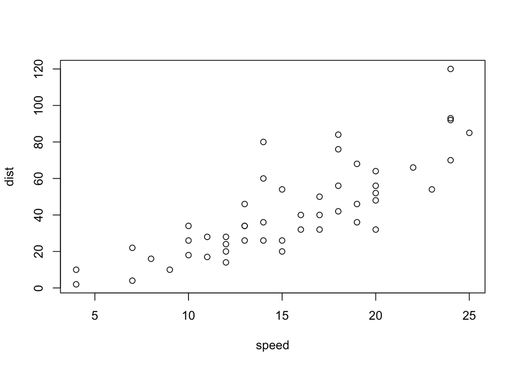

What about additional formating when displaying the contens of a table? Note the **asis** option

```r
knitr::kable(mtcars)
```

|  | mpg | cyl | disp | hp | drat | wt | qsec | vs | am | gear | carb |
| --- | --- | --- | --- | --- | --- | --- | --- | --- | --- | --- | --- |
| Mazda RX4 | 21.0 | 6 | 160.0 | 110 | 3.90 | 2.620 | 16.46 | 0 | 1 | 4 | 4 |
| Mazda RX4 Wag | 21.0 | 6 | 160.0 | 110 | 3.90 | 2.875 | 17.02 | 0 | 1 | 4 | 4 |
| Datsun 710 | 22.8 | 4 | 108.0 | 93 | 3.85 | 2.320 | 18.61 | 1 | 1 | 4 | 1 |
| Hornet 4 Drive | 21.4 | 6 | 258.0 | 110 | 3.08 | 3.215 | 19.44 | 1 | 0 | 3 | 1 |
| Hornet Sportabout | 18.7 | 8 | 360.0 | 175 | 3.15 | 3.440 | 17.02 | 0 | 0 | 3 | 2 |
| Valiant | 18.1 | 6 | 225.0 | 105 | 2.76 | 3.460 | 20.22 | 1 | 0 | 3 | 1 |
| Duster 360 | 14.3 | 8 | 360.0 | 245 | 3.21 | 3.570 | 15.84 | 0 | 0 | 3 | 4 |
| Merc 240D | 24.4 | 4 | 146.7 | 62 | 3.69 | 3.190 | 20.00 | 1 | 0 | 4 | 2 |
| Merc 230 | 22.8 | 4 | 140.8 | 95 | 3.92 | 3.150 | 22.90 | 1 | 0 | 4 | 2 |
| Merc 280 | 19.2 | 6 | 167.6 | 123 | 3.92 | 3.440 | 18.30 | 1 | 0 | 4 | 4 |
| Merc 280C | 17.8 | 6 | 167.6 | 123 | 3.92 | 3.440 | 18.90 | 1 | 0 | 4 | 4 |
| Merc 450SE | 16.4 | 8 | 275.8 | 180 | 3.07 | 4.070 | 17.40 | 0 | 0 | 3 | 3 |
| Merc 450SL | 17.3 | 8 | 275.8 | 180 | 3.07 | 3.730 | 17.60 | 0 | 0 | 3 | 3 |
| Merc 450SLC | 15.2 | 8 | 275.8 | 180 | 3.07 | 3.780 | 18.00 | 0 | 0 | 3 | 3 |
| Cadillac Fleetwood | 10.4 | 8 | 472.0 | 205 | 2.93 | 5.250 | 17.98 | 0 | 0 | 3 | 4 |
| Lincoln Continental | 10.4 | 8 | 460.0 | 215 | 3.00 | 5.424 | 17.82 | 0 | 0 | 3 | 4 |
| Chrysler Imperial | 14.7 | 8 | 440.0 | 230 | 3.23 | 5.345 | 17.42 | 0 | 0 | 3 | 4 |
| Fiat 128 | 32.4 | 4 | 78.7 | 66 | 4.08 | 2.200 | 19.47 | 1 | 1 | 4 | 1 |
| Honda Civic | 30.4 | 4 | 75.7 | 52 | 4.93 | 1.615 | 18.52 | 1 | 1 | 4 | 2 |
| Toyota Corolla | 33.9 | 4 | 71.1 | 65 | 4.22 | 1.835 | 19.90 | 1 | 1 | 4 | 1 |
| Toyota Corona | 21.5 | 4 | 120.1 | 97 | 3.70 | 2.465 | 20.01 | 1 | 0 | 3 | 1 |
| Dodge Challenger | 15.5 | 8 | 318.0 | 150 | 2.76 | 3.520 | 16.87 | 0 | 0 | 3 | 2 |
| AMC Javelin | 15.2 | 8 | 304.0 | 150 | 3.15 | 3.435 | 17.30 | 0 | 0 | 3 | 2 |
| Camaro Z28 | 13.3 | 8 | 350.0 | 245 | 3.73 | 3.840 | 15.41 | 0 | 0 | 3 | 4 |
| Pontiac Firebird | 19.2 | 8 | 400.0 | 175 | 3.08 | 3.845 | 17.05 | 0 | 0 | 3 | 2 |
| Fiat X1-9 | 27.3 | 4 | 79.0 | 66 | 4.08 | 1.935 | 18.90 | 1 | 1 | 4 | 1 |
| Porsche 914-2 | 26.0 | 4 | 120.3 | 91 | 4.43 | 2.140 | 16.70 | 0 | 1 | 5 | 2 |
| Lotus Europa | 30.4 | 4 | 95.1 | 113 | 3.77 | 1.513 | 16.90 | 1 | 1 | 5 | 2 |
| Ford Pantera L | 15.8 | 8 | 351.0 | 264 | 4.22 | 3.170 | 14.50 | 0 | 1 | 5 | 4 |
| Ferrari Dino | 19.7 | 6 | 145.0 | 175 | 3.62 | 2.770 | 15.50 | 0 | 1 | 5 | 6 |
| Maserati Bora | 15.0 | 8 | 301.0 | 335 | 3.54 | 3.570 | 14.60 | 0 | 1 | 5 | 8 |
| Volvo 142E | 21.4 | 4 | 121.0 | 109 | 4.11 | 2.780 | 18.60 | 1 | 1 | 4 | 2 |

## Tibble

What is tibble?

- modern way or loooking at the traditional data.frame
- you will get a lot more useful information than the data.frames
- tibble is part of tibble package and part of the core tidyverse package

To get help, use

```r
?tibble
vignette("tibble")
```

How to create a tibble?

```r
tibble(
  x = 1:5,
  y = LETTERS[1:5],
  z = x^2 + 20
)
```

```
## # A tibble: 5 × 3
##       x     y     z
##   <int> <chr> <dbl>
## 1     1     A    21
## 2     2     B    24
## 3     3     C    29
## 4     4     D    36
## 5     5     E    45
```

What is the difference between the R regular data.frame and tibble (data_frame)?

```r
employee <- c('John Wayne','Peter Doe','Esther Julie')
salary <- c(20000, 23400, 26800)
startdate <- as.Date(c('2016-12-1','2007-3-25','2016-3-14'))
df <- data.frame(employee, salary, startdate)
df
```

```
##       employee salary  startdate
## 1   John Wayne  20000 2016-12-01
## 2    Peter Doe  23400 2007-03-25
## 3 Esther Julie  26800 2016-03-14
```

```r
as_tibble(df)
```

```
## # A tibble: 3 × 3
##       employee salary  startdate
##         <fctr>  <dbl>     <date>
## 1   John Wayne  20000 2016-12-01
## 2    Peter Doe  23400 2007-03-25
## 3 Esther Julie  26800 2016-03-14
```

you can coerce regular R data frame into tibble. Let us look at the R dataset, cars. Let us learn about cars datset

```r
class(cars)
```

```
## [1] "data.frame"
```

```r
as_tibble(cars)
```

```
## # A tibble: 50 × 2
##    speed  dist
##    <dbl> <dbl>
## 1      4     2
## 2      4    10
## 3      7     4
## 4      7    22
## 5      8    16
## 6      9    10
## 7     10    18
## 8     10    26
## 9     10    34
## 10    11    17
## # ... with 40 more rows
```

```r
head(cars) #otherwise you get all 50 rows
```

```
##   speed dist
## 1     4    2
## 2     4   10
## 3     7    4
## 4     7   22
## 5     8   16
## 6     9   10
```

## Why Tibble?

- Tibble doesnt change the inputs. Ex. strings to factors
- Doesnt add new names or modify the inputs
- For example, Tibble never converts strings to factors

## What is tribble

- transposed tibble, tribble()
- small data in readable form
- column headings are shown as formulas ( ie ~ )
- nice format
- no need to explicitely use head command (Ex. head cars)

```r
tribble(
  ~x, ~y, ~z,
  #--|--|----
  "Male", 187, 210,
  "Female", 190, 150
)
```

```
## # A tibble: 2 × 3
##        x     y     z
##    <chr> <dbl> <dbl>
## 1   Male   187   210
## 2 Female   190   150
```

Let us create a little bit complicated tibble note that lubridate gives the current time

```r
t2 <- tibble(
  a = lubridate::now() + runif(1e3) * 86400,
  b = lubridate::today() + runif(1e3) * 30,
  c = 1:1e3,
  d = runif(1e3),
  e = sample(letters, 1e3, replace = TRUE)
)
```

```r
t2
```

```
## # A tibble: 1,000 × 5
##                      a          b     c          d     e
##                 <dttm>     <date> <int>      <dbl> <chr>
## 1  2017-03-06 23:08:00 2017-04-03     1 0.91336311     v
## 2  2017-03-06 14:33:53 2017-04-03     2 0.52086373     n
## 3  2017-03-07 00:25:21 2017-03-25     3 0.99086598     m
## 4  2017-03-06 12:50:17 2017-03-26     4 0.12060549     f
## 5  2017-03-06 11:52:25 2017-04-01     5 0.56085141     y
## 6  2017-03-06 17:50:01 2017-03-21     6 0.17567066     b
## 7  2017-03-07 00:40:25 2017-03-07     7 0.65049187     x
## 8  2017-03-06 19:09:07 2017-03-23     8 0.05092662     v
## 9  2017-03-06 12:27:40 2017-03-15     9 0.01106114     t
## 10 2017-03-06 23:34:17 2017-03-18    10 0.30961188     w
## # ... with 990 more rows
```

You can change the defaults of tibble display with options.

```r
options(tibble.print_max = 10, tibble.print_min = 6)
t2
```

```
## # A tibble: 1,000 × 5
##                     a          b     c         d     e
##                <dttm>     <date> <int>     <dbl> <chr>
## 1 2017-03-06 23:08:00 2017-04-03     1 0.9133631     v
## 2 2017-03-06 14:33:53 2017-04-03     2 0.5208637     n
## 3 2017-03-07 00:25:21 2017-03-25     3 0.9908660     m
## 4 2017-03-06 12:50:17 2017-03-26     4 0.1206055     f
## 5 2017-03-06 11:52:25 2017-04-01     5 0.5608514     y
## 6 2017-03-06 17:50:01 2017-03-21     6 0.1756707     b
## # ... with 994 more rows
```

You can also use the following tibble option to show all columns

```r
options(tibble.width = Inf)
# more options available at
package?tibble
```

How to extract the columns or rows of tibble?

```r
head(t2$a)
```

```
## [1] "2017-03-06 23:08:00 EST" "2017-03-06 14:33:53 EST"
## [3] "2017-03-07 00:25:21 EST" "2017-03-06 12:50:17 EST"
## [5] "2017-03-06 11:52:25 EST" "2017-03-06 17:50:01 EST"
```

```r
has_name(t2, "b")
```

```
## [1] TRUE
```

```r
getOption("tibble.max_extra_cols")
```

[output not shown]

how to add a row of a tibble in a specific place?

original t2

```r
t2
```

```
## # A tibble: 1,000 × 5
##                     a          b     c         d     e
##                <dttm>     <date> <int>     <dbl> <chr>
## 1 2017-03-06 23:08:00 2017-04-03     1 0.9133631     v
## 2 2017-03-06 14:33:53 2017-04-03     2 0.5208637     n
## 3 2017-03-07 00:25:21 2017-03-25     3 0.9908660     m
## 4 2017-03-06 12:50:17 2017-03-26     4 0.1206055     f
## 5 2017-03-06 11:52:25 2017-04-01     5 0.5608514     y
## 6 2017-03-06 17:50:01 2017-03-21     6 0.1756707     b
## # ... with 994 more rows
```

```r
    aa = lubridate::today()
    bb = lubridate::now()
    cc = 1:1
    dd = runif(1)
    ee = sample(letters, 1, replace = TRUE)
    print(aa); print(bb); print(cc); print(dd); print(ee)
```

```
## [1] "2017-03-06"
```

```
## [1] "2017-03-06 10:25:01 EST"
```

```
## [1] 1
```

```
## [1] 0.740969
```

```
## [1] "g"
```

```r
t2 %>%
  add_row(
    a = aa,
    b = bb,
    c = cc,
    d = dd,
    e = ee, .before = 2  # note the dot in ".before = 2"
)
```

```
## # A tibble: 1,001 × 5
##                     a          b     c         d     e
##                <dttm>     <date> <int>     <dbl> <chr>
## 1 2017-03-06 23:08:00 2017-04-03     1 0.9133631     v
## 2 2017-03-05 19:00:00 2017-03-06     1 0.7409690     g
## 3 2017-03-06 14:33:53 2017-04-03     2 0.5208637     n
## 4 2017-03-07 00:25:21 2017-03-25     3 0.9908660     m
## 5 2017-03-06 12:50:17 2017-03-26     4 0.1206055     f
## 6 2017-03-06 11:52:25 2017-04-01     5 0.5608514     y
## # ... with 995 more rows
```

After the change

```r
t2
```

```
## # A tibble: 1,000 × 5
##                     a          b     c         d     e
##                <dttm>     <date> <int>     <dbl> <chr>
## 1 2017-03-06 23:08:00 2017-04-03     1 0.9133631     v
## 2 2017-03-06 14:33:53 2017-04-03     2 0.5208637     n
## 3 2017-03-07 00:25:21 2017-03-25     3 0.9908660     m
## 4 2017-03-06 12:50:17 2017-03-26     4 0.1206055     f
## 5 2017-03-06 11:52:25 2017-04-01     5 0.5608514     y
## 6 2017-03-06 17:50:01 2017-03-21     6 0.1756707     b
## # ... with 994 more rows
```

## Subsetting

- $ by name

```r
df <- tibble(
  x = runif(5),
  y = rnorm(5)
)

df$x
```

```
## [1] 0.2058316 0.5992921 0.6761009 0.9891879 0.2828895
```

```r
df[[1]]
```

```
## [1] 0.2058316 0.5992921 0.6761009 0.9891879 0.2828895
```

Can you use Tibble in a pipeline?

```r
df %>% .$x
```

```
## [1] 0.2058316 0.5992921 0.6761009 0.9891879 0.2828895
```

```r
df %>% .[["y"]]
```

```
## [1]  0.4165373 -0.1832026  0.7068603 -0.5117995  2.0786768
```

What happens if tibble doesnt work with a package? Transform Tibble back to a data.frame using the following command:

```r
as.data.frame(df)
```

```
##           x          y
## 1 0.2058316  0.4165373
## 2 0.5992921 -0.1832026
## 3 0.6761009  0.7068603
## 4 0.9891879 -0.5117995
## 5 0.2828895  2.0786768
```

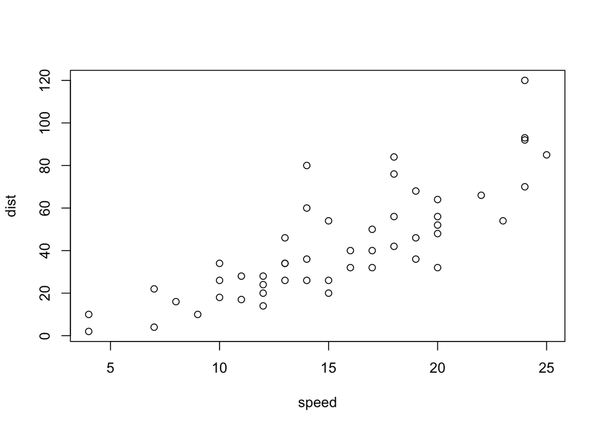

cars

```r
with(cars, plot(speed,dist))
```

## Tibble Exercise 1

Create a new tibble with the following information: name, age, height, weight, smoker (T or F), Male (True or Fale) compare the tibble with the R data_frame

## Exercise 2

convert iris data set (given to us in data.frame ) to tibble data_frame

## Exercise 3

How can you tell whether the object is a Tibble or not?

## Exercise 4 (based on Wickam’s book)

Partial matching is a big issue with data.frame. df <- data.frame(abc = 1, xyz = “a”) df$x df[, “xyz”]